# EDA-Technical Appendix-Quick Project

Wei Li & Florence Yan

January 30, 2019

# Load packages “tidyverse” and “ggplot2”

```r
library(tidyverse)
library(ggplot2)
```

# Load data

```r
# load data
sale <- read.csv('5210_W19_QP1_Data.csv')

# review data
str(sale)
```

```
## 'data.frame':    9994 obs. of  13 variables:
##  $ Order.ID    : Factor w/ 5009 levels "CA-2011-100006",..: 2501 2501 2297 4373 4373 202 202 202 202 202 ...
##  $ Ship.Mode   : Factor w/ 4 levels "First Class",..: 3 3 3 4 4 4 4 4 4 4 ...
##  $ Customer.ID : Factor w/ 793 levels "AA-10315","AA-10375",..: 144 144 240 706 706 89 89 89 89 89 ...
##  $ Region      : Factor w/ 4 levels "Central","East",..: 3 3 4 3 3 4 4 4 4 4 ...
##  $ Segment     : Factor w/ 3 levels "Consumer","Corporate",..: 1 1 2 1 1 1 1 1 1 1 ...
##  $ Category    : Factor w/ 3 levels "Furniture","Office Supplies",..: 1 1 2 1 2 1 2 3 2 2 ...
##  $ Sub.Category: Factor w/ 17 levels "Accessories",..: 5 6 11 17 15 10 3 14 4 2 ...
##  $ Product.Name: Factor w/ 1850 levels "\"While you Were Out\" Message Book, One Form per Page",..: 387 833 1440 368 574 570 1137 1099 535 295 ...
##  $ Product.ID  : Factor w/ 1862 levels "FUR-BO-10000112",..: 13 56 947 320 1317 186 563 1762 795 438 ...
##  $ Quantity    : int  2 3 2 5 2 7 4 6 3 5 ...
##  $ Revenue     : num  262 731.9 14.6 957.6 22.4 ...
##  $ Discount    : num  0 0 0 0.45 0.2 0 0 0.2 0.2 0 ...
##  $ Profit      : num  41.91 219.58 6.87 -383.03 2.52 ...
```

**Findings:**

- The data are in correct types.
- There are 9994 observations.
- There are 13 variables.
- Unit price and total cost are missing in the columns and can be calculated.

```r
summary(sale)
```

```
##            Order.ID             Ship.Mode      Customer.ID
##  CA-2014-100111:  14   First Class   :1538   WB-21850:  37
##  CA-2014-157987:  12   Same Day      : 543   JL-15835:  34
##  CA-2013-165330:  11   Second Class  :1945   MA-17560:  34
##  US-2013-108504:  11   Standard Class:5968   PP-18955:  34
##  CA-2012-131338:  10                         CK-12205:  32
##  CA-2013-105732:  10                         EH-13765:  32
##  (Other)       :9926                         (Other) :9791
##      Region            Segment                Category
##  Central:2323   Consumer   :5191   Furniture      :2121
##  East   :2848   Corporate  :3020   Office Supplies:6026
##  South  :1620   Home Office:1783   Technology     :1847
##  West   :3203
##
##
##
##       Sub.Category                      Product.Name
##  Binders    :1523   Staple envelope           :  48
##  Paper      :1370   Easy-staple paper         :  46
##  Furnishings: 957   Staples                   :  46
##  Phones     : 889   Avery Non-Stick Binders   :  20
##  Storage    : 846   Staples in misc. colors   :  19
##  Art        : 796   KI Adjustable-Height Table:  18
##  (Other)    :3613   (Other)                   :9797
##            Product.ID      Quantity        Revenue
##  OFF-PA-10001970:  19   Min.   : 1.00   Min.   :    0.444
##  TEC-AC-10003832:  18   1st Qu.: 2.00   1st Qu.:   17.280
##  FUR-FU-10004270:  16   Median : 3.00   Median :   54.490
##  FUR-CH-10001146:  15   Mean   : 3.79   Mean   :  229.858
##  FUR-CH-10002647:  15   3rd Qu.: 5.00   3rd Qu.:  209.940
##  TEC-AC-10002049:  15   Max.   :14.00   Max.   :22638.480
##  (Other)        :9896
##     Discount          Profit
##  Min.   :0.0000   Min.   :-6599.978
##  1st Qu.:0.0000   1st Qu.:    1.729
##  Median :0.2000   Median :    8.666
##  Mean   :0.1562   Mean   :   28.657
##  3rd Qu.:0.2000   3rd Qu.:   29.364
##  Max.   :0.8000   Max.   : 8399.976
##
```

**Conclusion found from the observation:**

- There isn’t missing values. We assume the data set is complete and clean.
- There are returned customers.
- West area has the largest number of order records, while south area the smallest.
- Office supplies is the majority category.
- There is great loss in Profit. We might want to find out the cause of the loss.

# Base EDA

## Univariate non-graphical: Categorical

```r
region_tab <- rbind(table(sale$Region),
                    round(prop.table(table(sale$Region)), 2))
row.names(region_tab) <- c('Count', 'Proportion')
region_tab
```

```
##            Central    East   South    West
## Count      2323.00 2848.00 1620.00 3203.00
## Proportion    0.23    0.28    0.16    0.32
```

Most number of sales in West, least in South.

```r
category_tab <- rbind(table(sale$Category),
                    round(prop.table(table(sale$Category)), 2))
row.names(category_tab) <- c("Count", "Proportion")
category_tab
```

```
##            Furniture Office Supplies Technology
## Count        2121.00          6026.0    1847.00
## Proportion      0.21             0.6       0.18
```

Office supplies has the largest number in orders.

```r
subcategory_tab <- rbind(table(sale$Sub.Category),
                    round(prop.table(table(sale$Sub.Category)), 2))
row.names(subcategory_tab) <- c("Count", "Proportion")
subcategory_tab
```

```
##            Accessories Appliances    Art Binders Bookcases Chairs Copiers
## Count           775.00     466.00 796.00 1523.00    228.00 617.00   68.00
## Proportion        0.08       0.05   0.08    0.15      0.02   0.06    0.01
##            Envelopes Fasteners Furnishings Labels Machines   Paper Phones
## Count         254.00    217.00       957.0 364.00   115.00 1370.00 889.00
## Proportion      0.03      0.02         0.1   0.04     0.01    0.14   0.09
##            Storage Supplies Tables
## Count       846.00   190.00 319.00
## Proportion    0.08     0.02   0.03
```

- Binders sell most.
- Copiers and Machines sell least.

## Univaviate graphical: Categorical

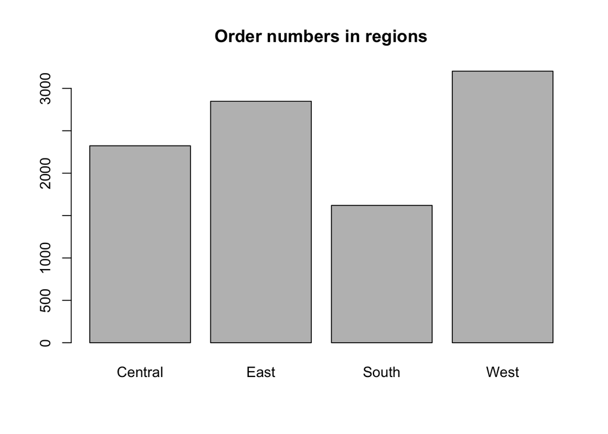

```r
barplot(table(sale$Region), main = "Order numbers in regions")
```

The sales records in West is almost twice of the South.

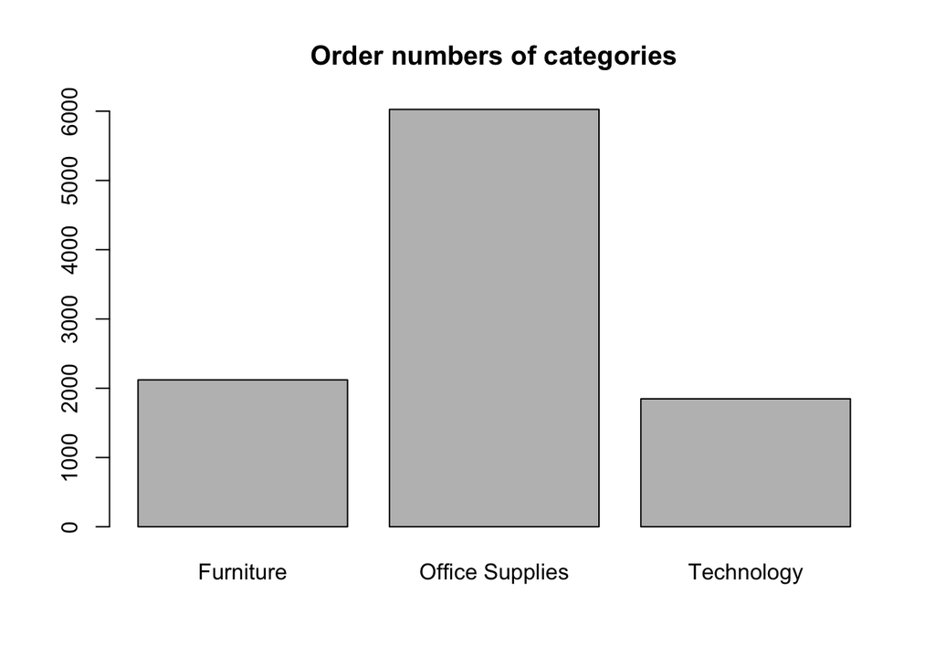

```r
barplot(table(sale$Category),
        main = "Order numbers of categories")
```

**Most of the orders are in Office Supplies Category. Here are the possible reasons:**

- The store’s name is “Office Mate”, so most of the customers would come here with specific shopping purpose for office supplies.
- The price of the products in office supplies category could be much lower than those in furniture and technology.
- The office supplies products consume faster than furnitures or technology products.

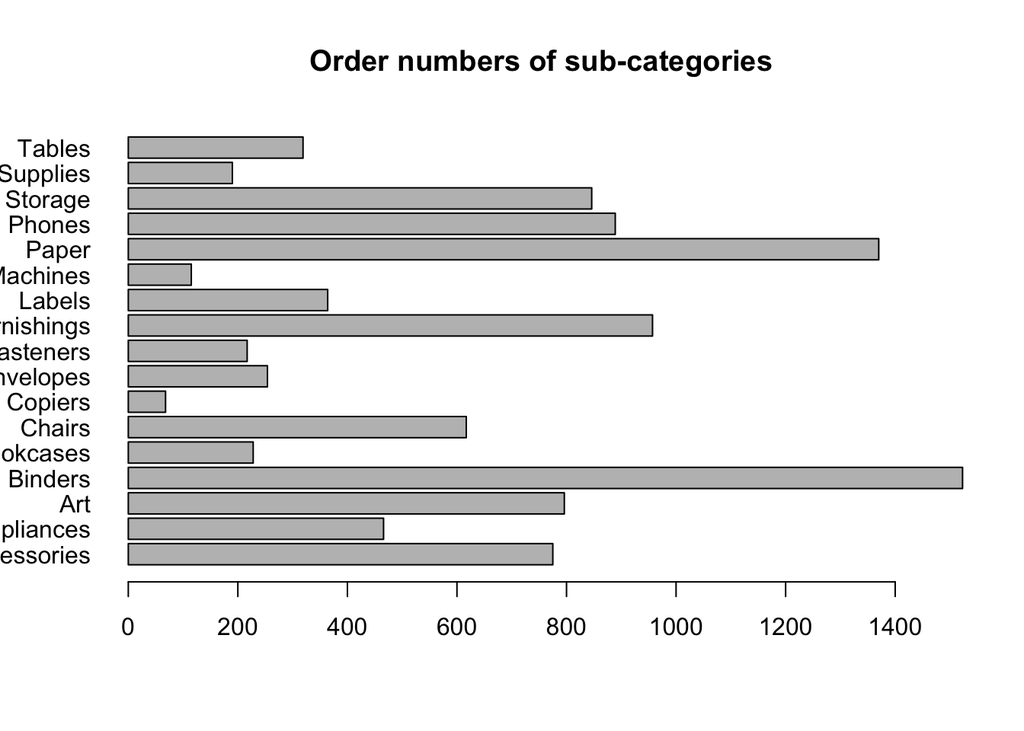

```r
barplot(table(sale$Sub.Category),
        main = "Order numbers of sub-categories",
        las = 1, horiz = TRUE)
```

This only shows the order numbers of each sub-category. However, we still need to explore more about the profits.

## Univariate non-graphical: Quantitative

```r
summary(sale)
```

```
##            Order.ID             Ship.Mode      Customer.ID
##  CA-2014-100111:  14   First Class   :1538   WB-21850:  37
##  CA-2014-157987:  12   Same Day      : 543   JL-15835:  34
##  CA-2013-165330:  11   Second Class  :1945   MA-17560:  34
##  US-2013-108504:  11   Standard Class:5968   PP-18955:  34
##  CA-2012-131338:  10                         CK-12205:  32
##  CA-2013-105732:  10                         EH-13765:  32
##  (Other)       :9926                         (Other) :9791
##      Region            Segment                Category
##  Central:2323   Consumer   :5191   Furniture      :2121
##  East   :2848   Corporate  :3020   Office Supplies:6026
##  South  :1620   Home Office:1783   Technology     :1847
##  West   :3203
##
##
##
##       Sub.Category                      Product.Name
##  Binders    :1523   Staple envelope           :  48
##  Paper      :1370   Easy-staple paper         :  46
##  Furnishings: 957   Staples                   :  46
##  Phones     : 889   Avery Non-Stick Binders   :  20
##  Storage    : 846   Staples in misc. colors   :  19
##  Art        : 796   KI Adjustable-Height Table:  18
##  (Other)    :3613   (Other)                   :9797
##            Product.ID      Quantity        Revenue
##  OFF-PA-10001970:  19   Min.   : 1.00   Min.   :    0.444
##  TEC-AC-10003832:  18   1st Qu.: 2.00   1st Qu.:   17.280
##  FUR-FU-10004270:  16   Median : 3.00   Median :   54.490
##  FUR-CH-10001146:  15   Mean   : 3.79   Mean   :  229.858
##  FUR-CH-10002647:  15   3rd Qu.: 5.00   3rd Qu.:  209.940
##  TEC-AC-10002049:  15   Max.   :14.00   Max.   :22638.480
##  (Other)        :9896
##     Discount          Profit
##  Min.   :0.0000   Min.   :-6599.978
##  1st Qu.:0.0000   1st Qu.:    1.729
##  Median :0.2000   Median :    8.666
##  Mean   :0.1562   Mean   :   28.657
##  3rd Qu.:0.2000   3rd Qu.:   29.364
##  Max.   :0.8000   Max.   : 8399.976
##
```

Three numerical and one integer variables differ in median and mean, indicating there should be skewness.

## Univariate graphical: Quantitative

**histograms**

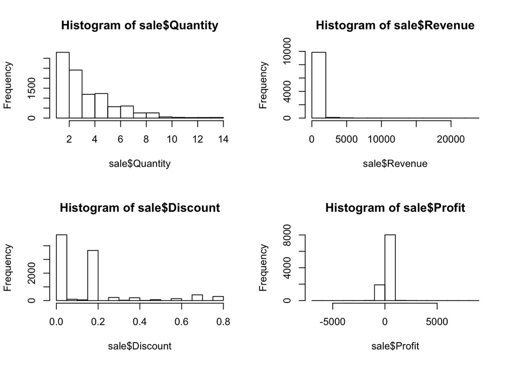

```r
par(mfrow = c(2, 2))
hist(sale$Quantity)
hist(sale$Revenue)
hist(sale$Discount)
hist(sale$Profit)
```

**Boxplots**

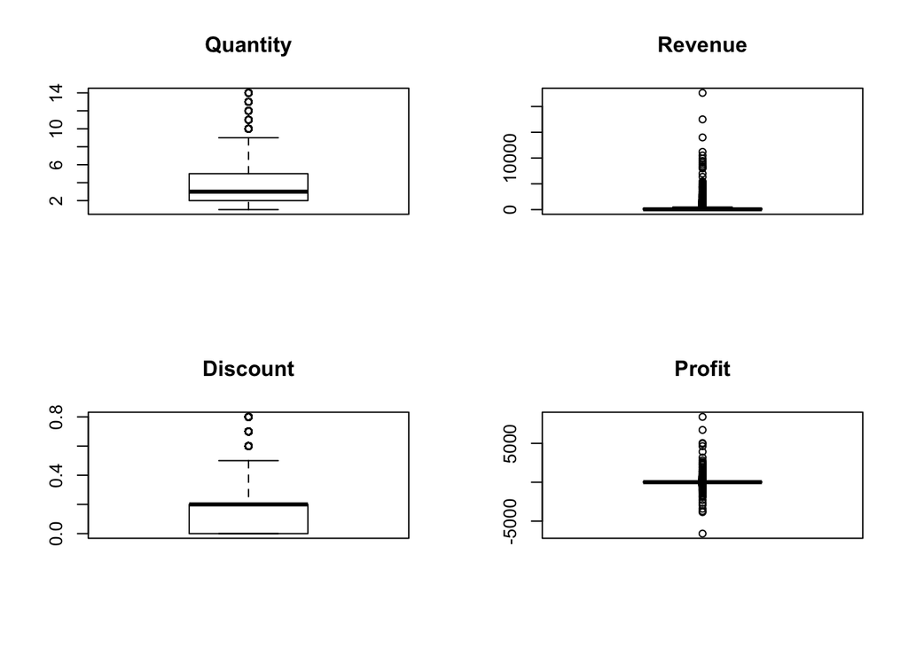

```r
par(mfrow = c(2, 2))
boxplot(sale$Quantity, main = "Quantity")
boxplot(sale$Revenue, main = "Revenue")
boxplot(sale$Discount, main = "Discount")
boxplot(sale$Profit, main = "Profit")
```

## Multivariate non-graphical: Categorical

```r
# Proportion of the order quantity of the three categories in four regions.
round(addmargins(prop.table(xtabs(~ Region + Category,  data = sale))), 2)
```

```
##          Category
## Region    Furniture Office Supplies Technology  Sum
##   Central      0.05            0.14       0.04 0.23
##   East         0.06            0.17       0.05 0.28
##   South        0.03            0.10       0.03 0.16
##   West         0.07            0.19       0.06 0.32
##   Sum          0.21            0.60       0.18 1.00
```

- We can reach the similar findings as those in previous graphical analysis.

## Multivariate graphical: Categorical

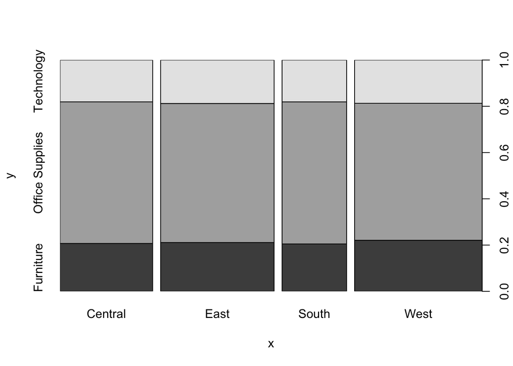

```r
plot(sale$Region, sale$Category)
```

Cannot tell much from the graph.

## Multivariate non-graphical: Quantitative

```r
# correlations between quantitative variables:
cor(sale[, 10:13])
```

```
##            Quantity     Revenue    Discount      Profit
## Quantity 1.00000000  0.20079477  0.00862297  0.06625319
## Revenue  0.20079477  1.00000000 -0.02819012  0.47906435
## Discount 0.00862297 -0.02819012  1.00000000 -0.21948746
## Profit   0.06625319  0.47906435 -0.21948746  1.00000000
```

- Revenue and Profit are most correlated among these variables.
- Discount and Quantity are least correlated.

## Multivariate graphical code – Quantitative

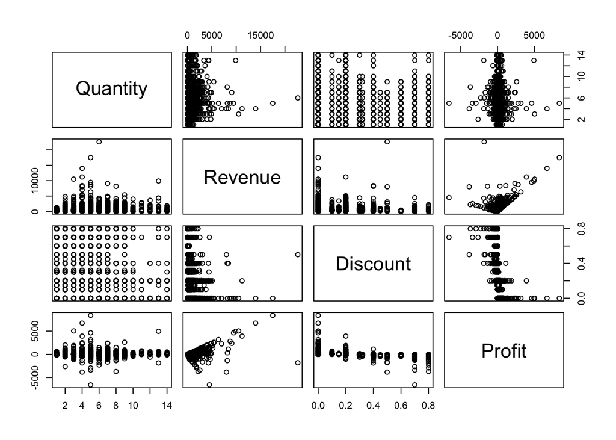

```r
plot(sale[, 10:13])
```

```r
library(psych)
```

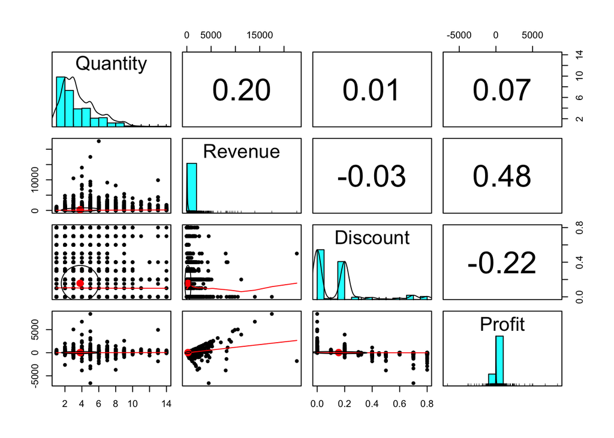

```r
pairs.panels(sale[, 10:13])
```

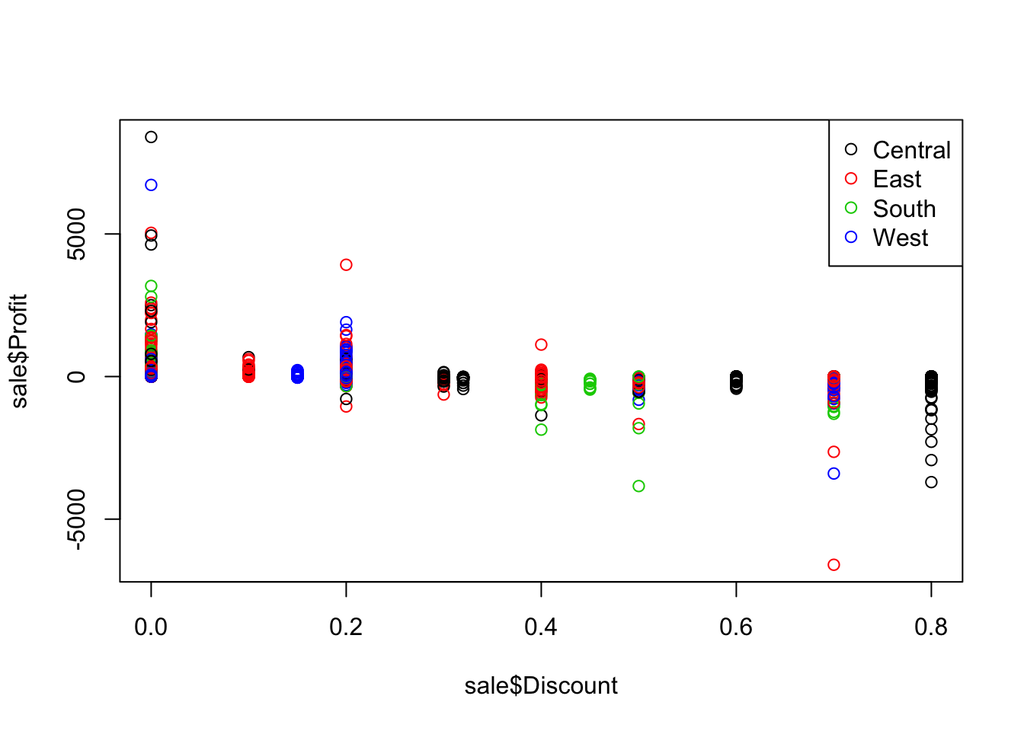

```r
plot(sale$Discount, sale$Profit, col = sale$Region)
legend(x = "topright",
       legend = levels(sale$Region),
       col = c(1:nlevels(sale$Region)),
       pch = 1)
```

Higher discount might bring lower profit.

## Multivariate non-graphical – Categorical and Quantitative

```r
profit_sum <- round(rbind(
  tapply(sale[sale$Region == "Central",]$Profit, sale[sale$Region == "Central",]$Sub.Category, sum),
  tapply(sale[sale$Region == "East",]$Profit, sale[sale$Region == "East",]$Sub.Category, sum),
  tapply(sale[sale$Region == "South",]$Profit, sale[sale$Region == "South",]$Sub.Category, sum),
  tapply(sale[sale$Region == "West",]$Profit, sale[sale$Region == "West",]$Sub.Category, sum)
  ), 0)
row.names(profit_sum) <- c("Central", "East", "South", "West")
profit_sum
```

```
##         Accessories Appliances  Art Binders Bookcases Chairs Copiers
## Central        7252      -2639 1195   -1044     -1998   6593   15609
## East          11196       8391 1900   11268     -1168   9358   17023
## South          7005       4124 1059    3901      1339   6612    3659
## West          16485       8261 2374   16097     -1647   4028   19327
##         Envelopes Fasteners Furnishings Labels Machines Paper Phones
## Central      1778       237       -3906   1073    -1486  6972  12323
## East         1812       264        5881   1129     6929  9015  12315
## South        1465       174        3443   1041    -1439  5947  10767
## West         1909       275        7641   2303     -619 12119   9111
##         Storage Supplies Tables
## Central    1970     -662  -3560
## East       8389    -1155 -11025
## South      2274        2  -4623
## West       8645      626   1483
```

**Indicating:**

- Tables and Bookcases are big profit losses.
- Copiers, Phones, and Accessories are most profitable.

```r
profit_med <- round(rbind(
  tapply(sale[sale$Region == "Central",]$Profit, sale[sale$Region == "Central",]$Sub.Category, median),
  tapply(sale[sale$Region == "East",]$Profit, sale[sale$Region == "East",]$Sub.Category, median),
  tapply(sale[sale$Region == "South",]$Profit, sale[sale$Region == "South",]$Sub.Category, median),
  tapply(sale[sale$Region == "West",]$Profit, sale[sale$Region == "West",]$Sub.Category, median)
  ),
  0)
row.names(profit_med) <- c("Central", "East", "South", "West")
profit_med
```

```
##         Accessories Appliances Art Binders Bookcases Chairs Copiers
## Central          16         -6   4      -4       -30     -7     305
## East             19         22   3       4         5     15     216
## South            18         19   3      -2        10     46     315
## West             28         23   4       7        11     14     435
##         Envelopes Fasteners Furnishings Labels Machines Paper Phones
## Central        13         3          -6      7       23     9     32
## East           14         3          10      7       36    11     12
## South          13         5           9      4      -12    12     33
## West           11         3          12      9       77    13     21
##         Storage Supplies Tables
## Central       5        2    -43
## East          8        4   -101
## South         6        5    -29
## West         10        5      7
```

We can see the same pattern as the previous one.

## Multivariate graphical: Categorical and Quantitative

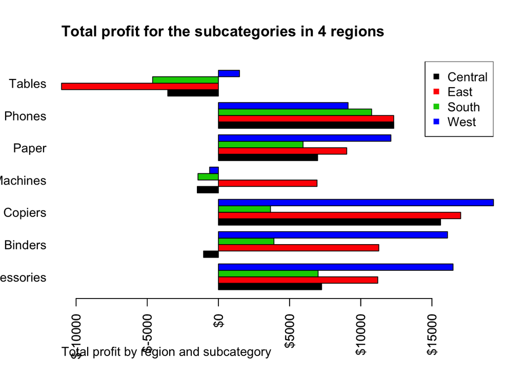

```r
keep_cat <- c("Accessories", "Binders", "Copiers", "Machines", "Paper", "Phones", "Tables")
small_tab <- profit_sum[, keep_cat]
barplot(small_tab,
        beside = TRUE,
        horiz = TRUE,
        las = 2,
        col = c(1:4),
        main = "Total profit for the subcategories in 4 regions",
        xlab = "Total profit by region and subcategory",
        adj = 0)
axis(1, at=axTicks(1), labels=sprintf("$%s", axTicks(1)), las = 2) # add $ to x-axis tics
legend(x = "topright",
       legend = levels(sale$Region),
       col = c(1:4),
       pch = 15)
```

# Two questions generated from basic EDA

- What are the most possible subcategories that can improve profits in the 4 regions?
- How does Discount affect profits?

# EDA through tidyverse to answer the two questions

## Q1: what are the most profit-potential subcategories in the for regions?

As we know this data set is from a big market formed by 4 regions. So there must be some similar characteristics among the 4 regions and thus they are comparable. So if one subcategory’s profit in one region is much lower than others, we can encourage the manager in this region to learn the sale strategies and methods for this subcategory from high-profit regions; likely, if the profit of a certain subcategory is higher than other regions, the manager also can share experience with managers in other areas. So that they can work together to improve the whole company’s profit.

```r
# See the most and least profitable subcategories in South region.
# First we create a table which contains the max and min profit of each subcategory, as a reference.
max_min <- sale %>%
  select(c(Category, Sub.Category, Region, Profit)) %>%
  group_by(Sub.Category, Region) %>%
  summarise(sum_prof = sum(Profit)) %>%
  group_by(Sub.Category) %>%
  summarise(max_prof = max(sum_prof),
            min_prof = min(sum_prof))

# Then we create a table to show the real profit of each subcategory in South.
south <- sale %>%
  select(c(Sub.Category, Region, Profit)) %>%
  filter(Region == 'South') %>%
  group_by(Sub.Category) %>%
  summarise(south_prof = sum(Profit))

# Then we can see the profitability levels of each subcategory in south area.
south %>%
  left_join(max_min, by = 'Sub.Category') %>%
  mutate(south_level = ifelse(south_prof == max_prof, 'Best',
                              ifelse(south_prof == min_prof, 'Worst', 'Normal')))
```

```
## # A tibble: 17 x 5
##    Sub.Category south_prof max_prof min_prof south_level
##    <fct>             <dbl>    <dbl>    <dbl> <chr>
##  1 Accessories     7005.     16485.    7005. Worst
##  2 Appliances      4124.      8391.   -2639. Normal
##  3 Art             1059.      2374.    1059. Worst
##  4 Binders         3901.     16097.   -1044. Normal
##  5 Bookcases       1339.      1339.   -1998. Best
##  6 Chairs          6612.      9358.    4028. Normal
##  7 Copiers         3659.     19327.    3659. Worst
##  8 Envelopes       1465.      1909.    1465. Worst
##  9 Fasteners        174.       275.     174. Worst
## 10 Furnishings     3443.      7641.   -3906. Normal
## 11 Labels          1041.      2303.    1041. Worst
## 12 Machines       -1439.      6929.   -1486. Normal
## 13 Paper           5947.     12119.    5947. Worst
## 14 Phones         10767.     12323.    9111. Normal
## 15 Storage         2274.      8645.    1970. Normal
## 16 Supplies           1.88     626.   -1155. Normal
## 17 Tables         -4623.      1483.  -11025. Normal
```

**Findings for South region:**

- The following subcategory, Accessories, Art, Copiers, Envelopes, Fasteners, Labels, Paper are under performing in South area. They make the least money compared with other 3 regions.
- The Bookcases subcategory is most profitable among the 4 regions.
- This analysis framework can be applied to the other three retions.

```r
# max_prof - min_prof = diff: reflect the 5 most wide-ranged profiting subcategories in 4 regions.
range_subCat <- max_min %>%
  mutate(diff = max_prof - min_prof) %>%
  arrange(desc(diff)) %>%
  top_n(4)
subCat_to_see <- range_subCat$Sub.Category # 4 categories of biggest interest to managers
```

- Since there is wide range of profits among the 4 regions in these subcategories, managers might be most interested in these subcategories.
- The idea is that if there is one region can make great profit in this subcategory, the other regions might also have potential to achieve the similar goal.

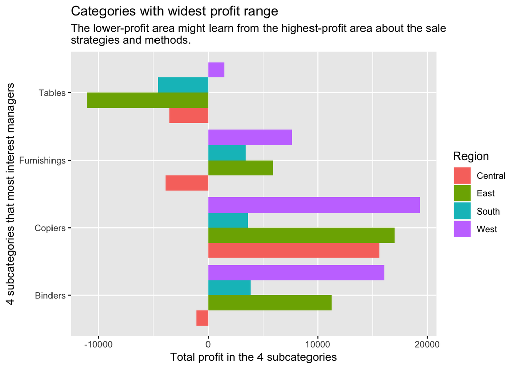

```r
sale %>%
  group_by(Sub.Category, Region) %>%
  summarise(prof_sum = sum(Profit)) %>%
  filter(Sub.Category %in% subCat_to_see) %>%
  ggplot(aes(Sub.Category, prof_sum, fill = Region))+
  geom_bar(stat = 'identity',
           position = 'dodge') +
  coord_flip() +
  ylab('Total profit in the 4 subcategories') +
  xlab('4 subcategories that most interest managers') +
  ggtitle("Categories with widest profit range",
          sub = "The lower-profit area might learn from the highest-profit area about the sale \nstrategies and methods.")
```

**Conclusions:**

- The subcategories that the managers in the 4 regions might be most interested are: Tables, Furnishings, Copiers, Binders.
- South, east, and central regions need to learn how to improve profits of tables. Or we can reduce table sales, since 3/4 of the regions are losing money.
- Central region need to find out the reasons for the negative profit in the Furnishings and Binders sales.
- South region might learn how to improve Copiers profits by learnig from other three regions.
- Generally speaking, west and east regions achieved good profits.

## Q2: How does discount affect profits?

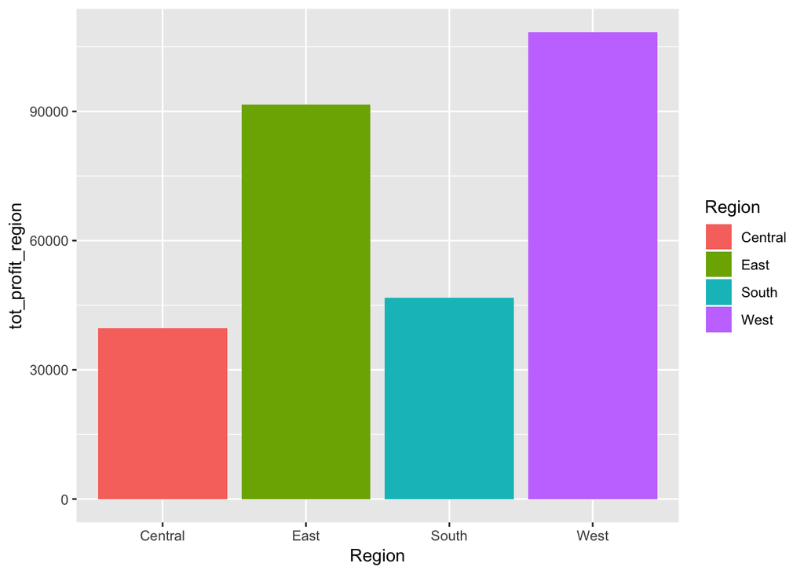

```r
sale %>%
  group_by(Region) %>%
  summarise(tot_profit_region = sum(Profit)) %>%
  ggplot(aes(Region, tot_profit_region, fill = Region)) +
  geom_bar(stat="identity", position = "dodge")
```

- As we see the most profitable region is West. While it is not the one which holds the biggest discount. Thus, we can conclude that more discount doesn’t contribute more profits.

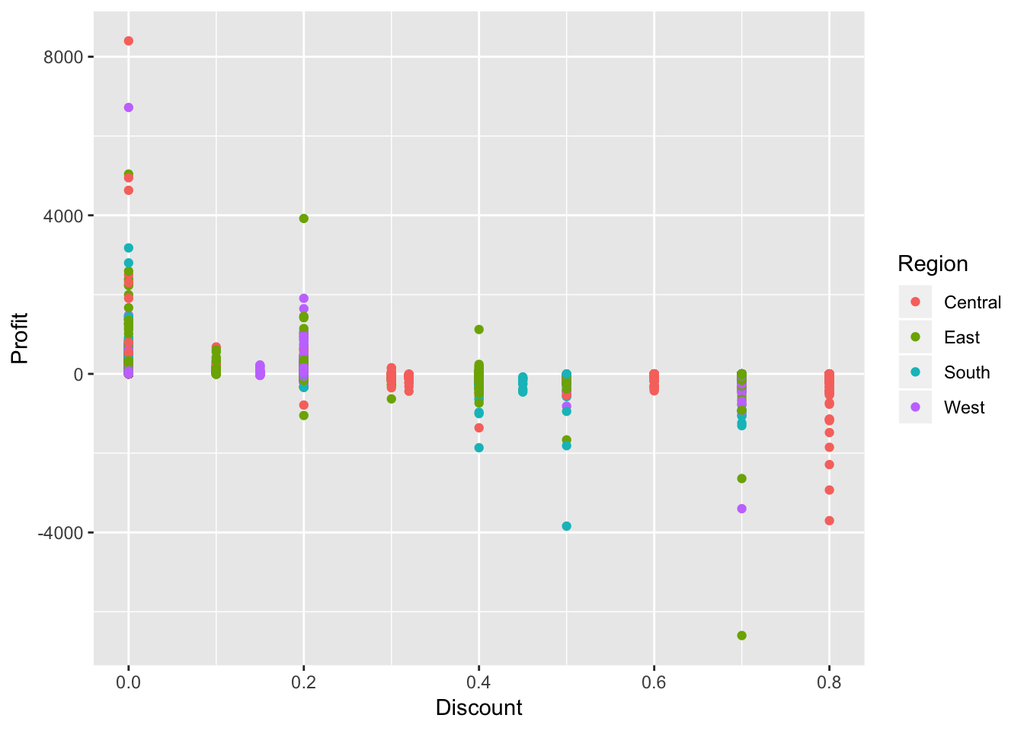

```r
sale %>%
  ggplot(aes(x=Discount, Profit, color = Region)) +
  geom_point()
```

In this case, we suggest the compnay adjust the discount strategy.

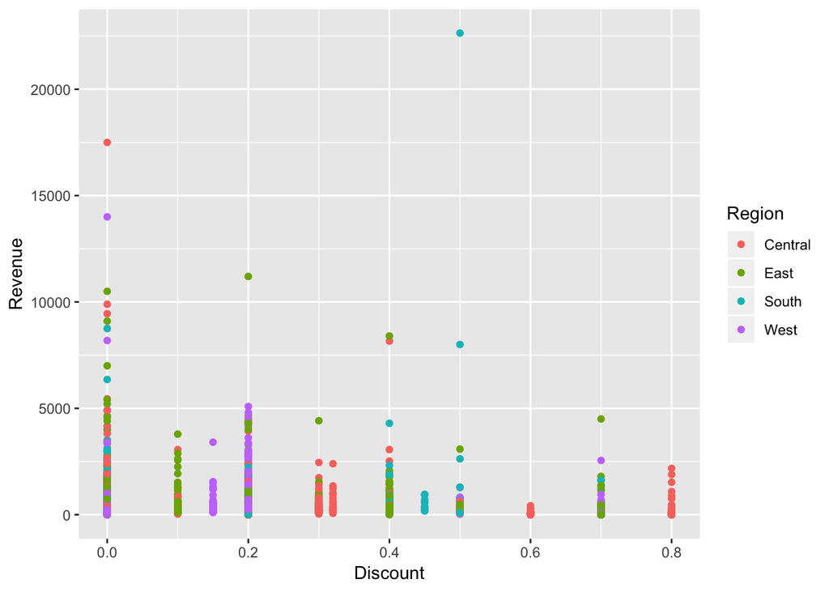

```r
sale %>%
  ggplot(aes(x=Discount, Revenue, color = Region)) +
  geom_point()
```

```r
sale %>%
  filter(Region == "South") %>%
  select(c(Region, Category, Revenue)) %>%
  group_by(Category) %>%
  summarise( max_revenue = max(Revenue))
```

```
## # A tibble: 3 x 2
##   Category        max_revenue
##   <fct>                 <dbl>
## 1 Furniture             4298.
## 2 Office Supplies       6355.
## 3 Technology           22638.
```